# dada2 to omeClust and MaAsLin2 pipeline

Clark Gaylord (cgaylord@gwu.edu)

12/16/2021

We wish to give a demonstration of using the dada2 denoising framework as an input to both omeClust and MaAsLin2 using data from Song, et al. Note that omeClust is an external application; though we will run it from this script, the output will go to a directory. MaAsLin2 also writes its output to a directory.

Our code is a simplified version of our analysis for the purposes of this tutorial.

The libraries we use are: lubridate tools dada2 ggplot2 bioDist Maaslin2

These are assumed to have been installed and available as libraries.

The first step in the dada2 pipeline is to trim and filter the low quality sequences from the data. We choose one of the samples arbitrarily to visualize its quality. Based on this (or any other) plots, you may choose to trim differently or to use a minimum quality score as a threshold, but we will trim the leftmost 25 and rightmost 10 bases from our samples.

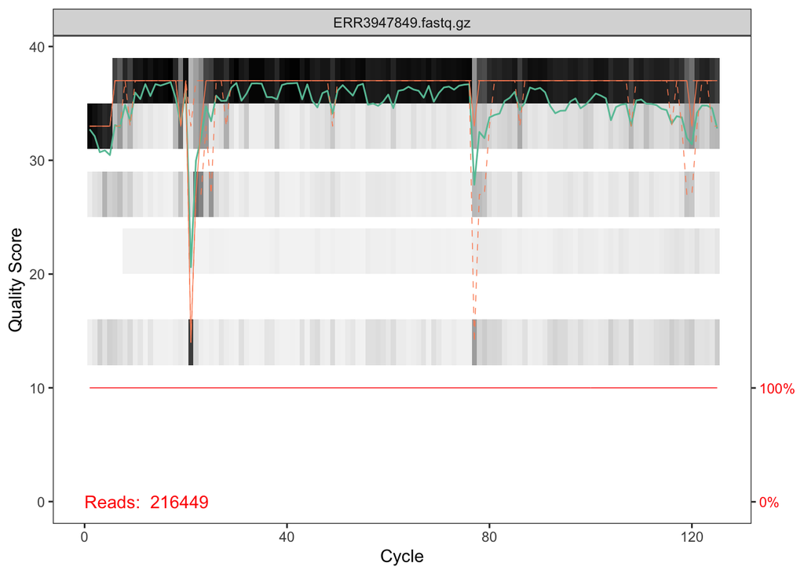

Some summarization of the filtered fastq reads

```r
head(filtFastqReads)
```

```
##            reads.in reads.out
## ERR1464420    33924     33448
## ERR1464446     9006      8878
## ERR1464459    25751     25429
## ERR1464475    32419     32000
## ERR1464486     8093      7982
## ERR1464501    24817     24512
```

```r
summary(filtFastqReads)
```

```
##     reads.in        reads.out
##  Min.   :    45   Min.   :    45
##  1st Qu.: 23796   1st Qu.: 23550
##  Median : 38224   Median : 37828
##  Mean   : 80443   Mean   : 80057
##  3rd Qu.:142332   3rd Qu.:141965
##  Max.   :370998   Max.   :370013
```

```r
print(paste(
    "Total reads ",
    sum(filtFastqReads[,1]),
    "and after filter",
    sum(filtFastqReads[,2])))
```

```
## [1] "Total reads  11101133 and after filter 11047917"
```

```r
print("The proportion of reads retained is")
```

```
## [1] "The proportion of reads retained is"
```

```r
sum( filtFastqReads[,2]) / sum(filtFastqReads[,1] )
```

```
## [1] 0.9952063
```

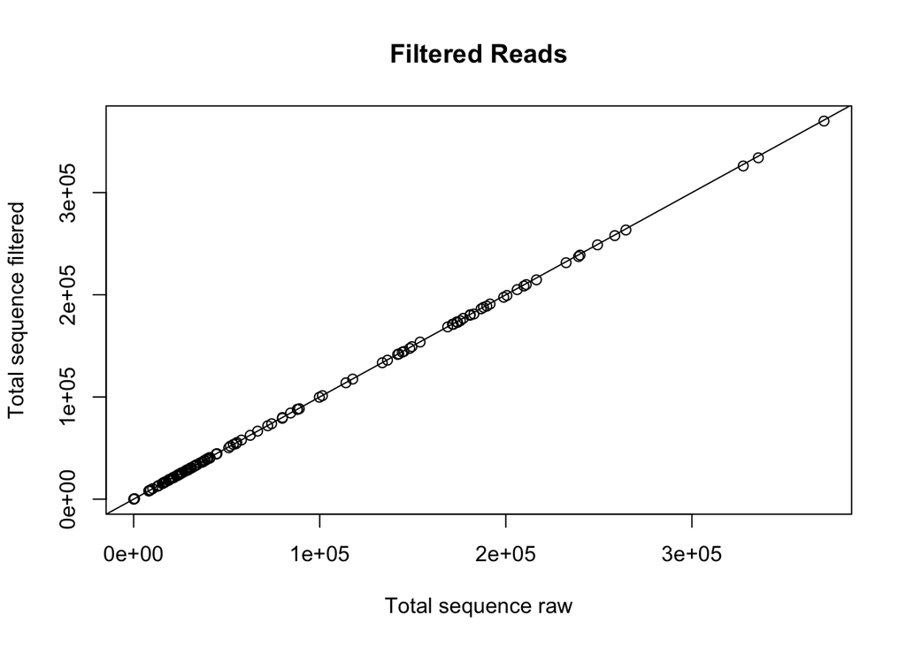

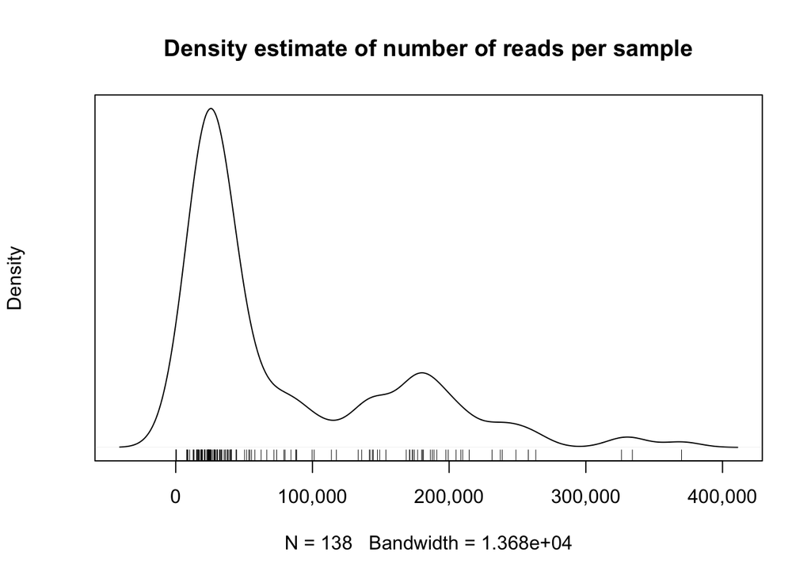

The dada algorthim uses an estimated error function as part of its input

```
## 101659726 total bases in 894286 reads from 35 samples will be used for learning the error rates.
```

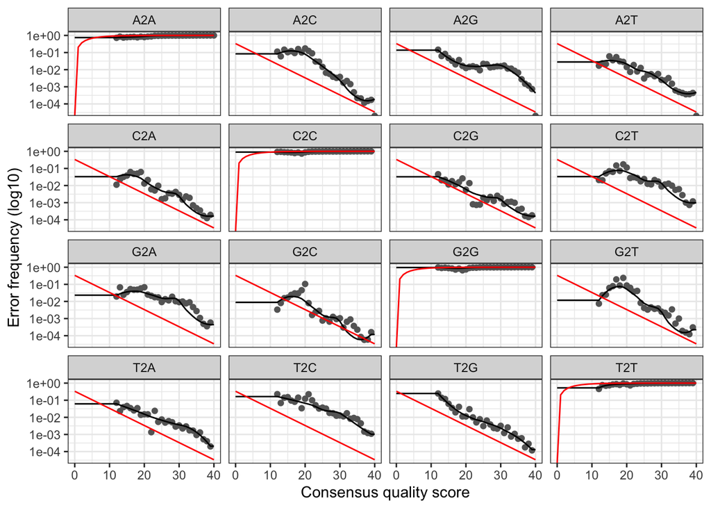

And finally, dada2 denoises the sequences so that we can have a matrix of features (the amplicon sequences themselves) from each sample.

```r
dada_Infant <- dada(
    Infant_ALL_filt_files,
    err = errRates,
    multithread = TRUE)
```

```
## Sample 1 - 33448 reads in 3512 unique sequences.
## Sample 2 - 8878 reads in 1282 unique sequences.
## Sample 3 - 25429 reads in 2129 unique sequences.
## Sample 4 - 32000 reads in 4259 unique sequences.
## Sample 5 - 7982 reads in 1243 unique sequences.
## Sample 6 - 24512 reads in 2993 unique sequences.
## Sample 7 - 12852 reads in 1557 unique sequences.
## Sample 8 - 40158 reads in 3488 unique sequences.
## Sample 9 - 36449 reads in 3100 unique sequences.
## Sample 10 - 26976 reads in 3943 unique sequences.
## Sample 11 - 23502 reads in 2755 unique sequences.
## Sample 12 - 15516 reads in 1666 unique sequences.
## Sample 13 - 22826 reads in 2462 unique sequences.
## Sample 14 - 24340 reads in 2032 unique sequences.
## Sample 15 - 32256 reads in 3181 unique sequences.
## Sample 16 - 40532 reads in 3551 unique sequences.
## Sample 17 - 38783 reads in 4627 unique sequences.
## Sample 18 - 12765 reads in 1270 unique sequences.
## Sample 19 - 8167 reads in 1248 unique sequences.
## Sample 20 - 29064 reads in 3637 unique sequences.
## Sample 21 - 23483 reads in 2681 unique sequences.
## Sample 22 - 23969 reads in 2613 unique sequences.
## Sample 23 - 18345 reads in 2211 unique sequences.
## Sample 24 - 27961 reads in 4121 unique sequences.
## Sample 25 - 17276 reads in 3210 unique sequences.
## Sample 26 - 20899 reads in 3524 unique sequences.
## Sample 27 - 50307 reads in 4589 unique sequences.
## Sample 28 - 21082 reads in 1953 unique sequences.
## Sample 29 - 37885 reads in 2244 unique sequences.
## Sample 30 - 36225 reads in 2508 unique sequences.
## Sample 31 - 21390 reads in 2080 unique sequences.
## Sample 32 - 30451 reads in 3384 unique sequences.
## Sample 33 - 28599 reads in 3502 unique sequences.
## Sample 34 - 23693 reads in 2339 unique sequences.
## Sample 35 - 16286 reads in 1824 unique sequences.
## Sample 36 - 168563 reads in 10295 unique sequences.
## Sample 37 - 87828 reads in 4992 unique sequences.
## Sample 38 - 257902 reads in 19931 unique sequences.
## Sample 39 - 25509 reads in 1686 unique sequences.
## Sample 40 - 484 reads in 184 unique sequences.
## Sample 41 - 99723 reads in 4983 unique sequences.
## Sample 42 - 143841 reads in 11768 unique sequences.
## Sample 43 - 57838 reads in 3116 unique sequences.
## Sample 44 - 62452 reads in 7119 unique sequences.
## Sample 45 - 141653 reads in 9949 unique sequences.
## Sample 46 - 55420 reads in 1871 unique sequences.
## Sample 47 - 39714 reads in 2405 unique sequences.
## Sample 48 - 147554 reads in 11349 unique sequences.
## Sample 49 - 66565 reads in 4587 unique sequences.
```

```
## The supplied error matrix does not extend to maximum observed Quality Scores in sample 50(q=41).
##                        Extending the error model by repeating the last column of the Error Matrix (column 41).
##                        In selfConsist mode this should converge to the proper error rates, otherwise this may not be what you want.
```

```
## Sample 50 - 79123 reads in 3691 unique sequences.
## Sample 51 - 197599 reads in 17662 unique sequences.
## Sample 52 - 179917 reads in 12250 unique sequences.
## Sample 53 - 180526 reads in 8974 unique sequences.
## Sample 54 - 117485 reads in 7869 unique sequences.
## Sample 55 - 135988 reads in 10080 unique sequences.
## Sample 56 - 190966 reads in 12922 unique sequences.
## Sample 57 - 172999 reads in 10543 unique sequences.
## Sample 58 - 334053 reads in 22335 unique sequences.
## Sample 59 - 326066 reads in 22406 unique sequences.
## Sample 60 - 238814 reads in 16230 unique sequences.
## Sample 61 - 171018 reads in 13876 unique sequences.
## Sample 62 - 19125 reads in 5131 unique sequences.
## Sample 63 - 40752 reads in 8536 unique sequences.
## Sample 64 - 16315 reads in 4166 unique sequences.
## Sample 65 - 18626 reads in 6712 unique sequences.
## Sample 66 - 15247 reads in 3559 unique sequences.
## Sample 67 - 297 reads in 134 unique sequences.
## Sample 68 - 10218 reads in 3230 unique sequences.
## Sample 69 - 44147 reads in 9599 unique sequences.
## Sample 70 - 26068 reads in 7732 unique sequences.
## Sample 71 - 30064 reads in 10474 unique sequences.
## Sample 72 - 15576 reads in 4680 unique sequences.
## Sample 73 - 33762 reads in 7465 unique sequences.
## Sample 74 - 71811 reads in 19984 unique sequences.
## Sample 75 - 24858 reads in 7180 unique sequences.
## Sample 76 - 25139 reads in 7993 unique sequences.
## Sample 77 - 18763 reads in 3678 unique sequences.
## Sample 78 - 18589 reads in 4584 unique sequences.
## Sample 79 - 19382 reads in 5113 unique sequences.
## Sample 80 - 16813 reads in 4515 unique sequences.
## Sample 81 - 16277 reads in 4624 unique sequences.
## Sample 82 - 37770 reads in 4593 unique sequences.
## Sample 83 - 33053 reads in 5956 unique sequences.
## Sample 84 - 22814 reads in 3336 unique sequences.
## Sample 85 - 40599 reads in 4894 unique sequences.
## Sample 86 - 27895 reads in 3172 unique sequences.
## Sample 87 - 28268 reads in 3124 unique sequences.
## Sample 88 - 40255 reads in 8261 unique sequences.
## Sample 89 - 25445 reads in 4998 unique sequences.
```

[output cut: 34 more lines]

```
## Sample 124 - 30663 reads in 30637 unique sequences.
## Sample 125 - 84288 reads in 3954 unique sequences.
## Sample 126 - 208587 reads in 22386 unique sequences.
## Sample 127 - 53492 reads in 3865 unique sequences.
## Sample 128 - 21466 reads in 2089 unique sequences.
## Sample 129 - 13461 reads in 1612 unique sequences.
## Sample 130 - 88502 reads in 6584 unique sequences.
## Sample 131 - 144513 reads in 8318 unique sequences.
## Sample 132 - 84 reads in 49 unique sequences.
## Sample 133 - 174583 reads in 17760 unique sequences.
## Sample 134 - 188899 reads in 16370 unique sequences.
## Sample 135 - 23783 reads in 1473 unique sequences.
## Sample 136 - 24079 reads in 1959 unique sequences.
## Sample 137 - 51874 reads in 3299 unique sequences.
## Sample 138 - 44491 reads in 3409 unique sequences.
```

How many sequences came out of the denoising?

```r
dim(seqTable_Infant)
```

```
## [1]  138 3332
```

```r
table(nchar(getSequences(seqTable_Infant)))
```

```
##
##   41   42   46   49   65   84   90   98  112  114  115  116
##    2    1    1    1   65    1 1594    1    3    2  578 1083
```

Now to remove chimeras, we are left with our features to analyze:

```r
seqTable_Infant.nochim <- removeBimeraDenovo(
    seqTable_Infant,
    method = "consensus",
    multithread = TRUE,
    verbose = TRUE)
```

```
## Identified 1500 bimeras out of 3332 input sequences.
```

```r
dim(seqTable_Infant.nochim)
```

```
## [1]  138 1832
```

```r
table(nchar(getSequences(seqTable_Infant.nochim)))
```

```
##
##  41  42  46  49  65  84  90  98 112 114 115 116
##   2   1   1   1  46   1 852   1   3   2 320 602
```

Let’s look at the abundance of a chosen sequence

```
## [1] "Example sequence is  AATTATTGGGCGTAAAGGGCTCGTAGGCGGTTCGTCGCGTCCGGTGTGAAAGTCCATCGCTTAACGGTGGATCCGCGCCGGGTACGGGCGGGCTTGAGTGCGGTAGGGGAGACTGG"
```

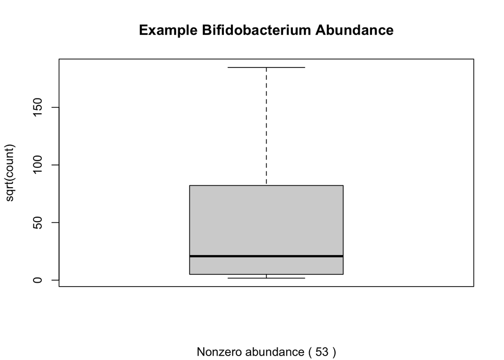

How many reads were filtered from each step of the pipeline (total number of reads and proportion from the initial set)?

```
##            input filtered denoisedF nonchim
## ERR1464420 33924    33448     33343   32843
## ERR1464446  9006     8878      8835    8608
## ERR1464459 25751    25429     25391   25140
## ERR1464475 32419    32000     31932   31612
## ERR1464486  8093     7982      7954    7531
## ERR1464501 24817    24512     24393   24188
```

```
##     input  filtered denoisedF   nonchim
##  11101133  11047917  10959361  10711123
```

```
##     input  filtered denoisedF   nonchim
## 1.0000000 0.9952063 0.9872291 0.9648676
```

Calling omeClust

```r
system(paste("omeClust -i ome_infant_distance.txt -o", omeClust_directory,"--metadata ome_infant_metadata.txt --plot"))
```

And now calling Maaslin2 (output is huge, so change this to echo=TRUE if you really want it)

```r
Maaslin2(
    sqrt(seqTable_Infant.nochim.df),
    birth_mode,
    output=maas_directory,
    reference = c("birth_mode", "CS"))
```

Now you can review the output in the respective directories.

Thank you for playing.